# R for Humanities: Lesson 6

[Main Menu](https://htmlpreview.github.io/?https://github.com/argentenum/Rworkshop/blob/master/notebooks/RforHumanities.nb.html)

# 1 manipulating strings

```r
pnpWords[42]
```

```
[1] "neighbourhood,"
```

## 1.1 obtaining a substring from a string

```r
substr(pnpWords[42],1,9)
```

```
[1] "neighbour"
```

## 1.2 splitting a string

```r
strsplit(pnpWords[42], split = "r")
```

```
[[1]]
[1] "neighbou" "hood,"
```

## 1.3 splitting words using white space

```r
strsplit("these are a few of my favourite things", split = " ")
```

```
[[1]]
[1] "these"     "are"       "a"         "few"       "of"        "my"
[7] "favourite" "things"
```

The result is a list

```r
str(strsplit("these are a few of my favourite things", split = " "))
```

```
List of 1
 $ : chr [1:8] "these" "are" "a" "few" ...
```

To get a Vector use unlist

```r
unlist(strsplit("these are a few of my favourite things", split = " "))
```

## 1.4 Import a text file as a single string

```r
pnpText <- readLines("https://web.iitd.ac.in/~arjunghosh/RworkshopFiles/pnp.txt")
```

```r
str(pnpText)
```

```
 chr "It is a truth universally acknowledged, that a single man in possession of a good fortune, must be in want of a"| __truncated__
```

## 1.5 parse sentences

```r
strsplit(pnpText, "\\.")
```

```
[[1]]
[1] "It is a truth universally acknowledged, that a single man in possession of a good fortune, must be in want of a wife"
[2] " However little known the feelings or views of such a man may be on his first entering a neighbourhood, this truth is so well fixed in the minds of the surrounding families, that he is considered the rightful property of some one or other of their daughters"
```

# 2 Solved exercise

Let us try to get a particular sonnet (“Shall I compare thee ….”) from a file containing all of Shakespeare’s sonnets.

## 2.1 importing the file

```r
sonnets <- readLines("https://www.gutenberg.org/files/1041/1041-0.txt")
```

The error “incomplete final line found on …” comes if the source file does not end with an End of Line character (eg. line ending or paragraph ending - “/n”)

Let us extract the lines containing the sonnet in question. For now we are indexing the lines based on a physical inspection of the file.

```r
sonnets[301:314]
```

```
 [1] "Shall I compare thee to a summer’s day?"
 [2] "Thou art more lovely and more temperate:"
 [3] "Rough winds do shake the darling buds of May,"
 [4] "And summer’s lease hath all too short a date:"
 [5] "Sometime too hot the eye of heaven shines,"
 [6] "And often is his gold complexion dimm’d,"
 [7] "And every fair from fair sometime declines,"
 [8] "By chance, or nature’s changing course untrimm’d:"
 [9] "But thy eternal summer shall not fade,"
[10] "Nor lose possession of that fair thou ow’st,"
[11] "Nor shall death brag thou wander’st in his shade,"
[12] "When in eternal lines to time thou grow’st,"
[13] "    So long as men can breathe, or eyes can see,"
[14] "    So long lives this, and this gives life to thee."
```

## 2.2 Trimming white space

We see that the some of the lines have additional white space in them. These are there in the source file for visual formatting. But if we want to parse the file for word extraction it would help if we remove the addtional white spaces.

```r
sonnet18 <- trimws(sonnets[301:314])
```

# 3 Regular expressions

So far we have been examining the text file physically to discover the lines of a sonnet to be extracted. What if we want to work with a very large file? In that case the physical examination may not be sufficient or even feasible. Though it is not advisable to abandon physical examination altogether, it is important to supplement it with computational examination. For that we need to take recourse to a set of text evaluation tools called Regular Expressions.

We will engage with the full suite of Regular Expressions tools later. Right now let us learn a few preliminary funtions.

## 3.1 grep

grep will give us the line or vector index where a particular substring pattern match is found.

```r
grep("Shall I compare", sonnets)
```

```
[1] 301
```

We have found the index of the first line of the our chosen sonnet.

Now since we know that the sonnet in question consists of 14 lines we can easily extract the sonnet.

```r
sonnets[grep("Shall I compare", sonnets):(grep("Shall I compare", sonnets)+13)]
```

# 4 Solved Exercise

Let us try to compute the total number of sonnets in the file.

Let us examine the file again.

We see that in this file each sonnet is preceeded by a sonnet number in roman numerals. If we can identify the indices of the “sonnets” vector that give these sonnet numbers we should be able to extract each sonnet in a loop.

Is there a way to identify these lines?

```r
nchar(sonnets)
```

The resulting vector is a very long file and it may be difficult to identify any useful pattern. It may be useful to resort to visual methods.

Though we have not yet learnt how to prepare charts in R let us visualize our output as a barplot.

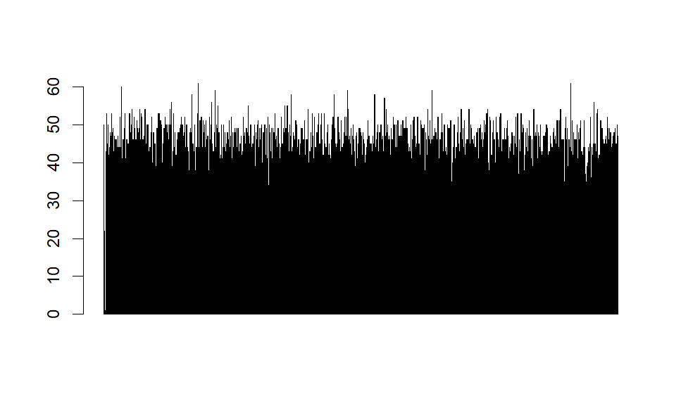

```r
barplot(nchar(sonnets))
```

We see that the line lengths are unequal but the density of the chart does not allow us to arrive at anything meaningful. Let us look a a subset of the Vector.

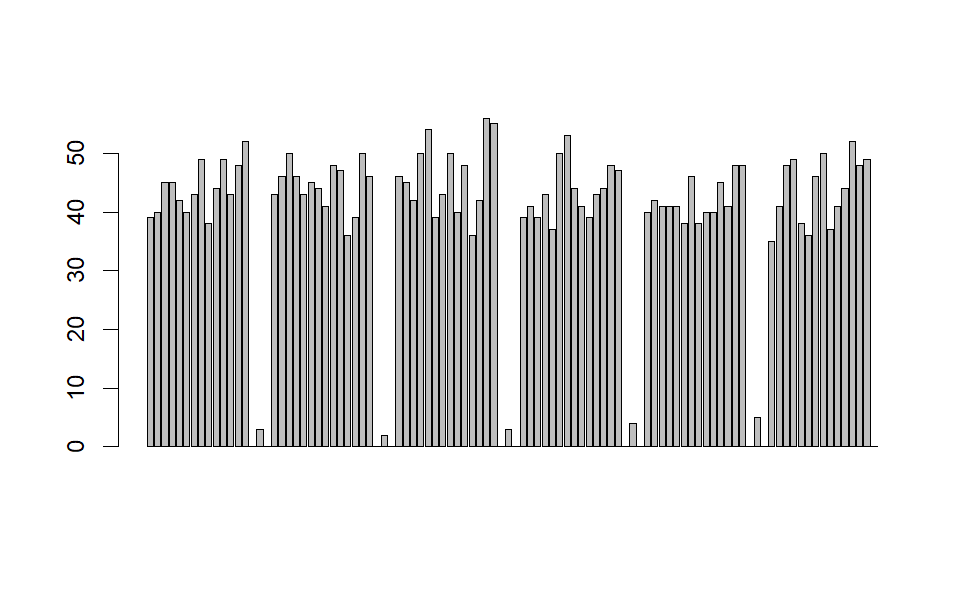

```r
barplot(nchar(sonnets[301:400]))
```

Now we get to see something more meaningful. We see that there is a pattern of the sonnets being divided by shorter strings consisting which have more than zero characters.

If we can identify the indices of these lines we should be able to identify the lines with the sonnet numbers.

We can do so by checking for strings that have greater than 0 but less than 10 characters.

```r
which(nchar(sonnets)>0 & nchar(sonnets)<10)
```

```
  [1]    9   26   43   60   77   95  112  129  146  163  180  197  214  231
 [15]  248  265  282  299  316  333  350  367  384  401  418  435  452  469
 [29]  486  503  520  537  554  571  588  605  622  639  656  673  690  707
 [43]  724  741  758  775  792  809  826  843  860  877  894  911  928  945
 [57]  962  979  996 1013 1030 1047 1064 1081 1098 1115 1132 1149 1166 1183
 [71] 1200 1217 1234 1251 1268 1285 1302 1319 1336 1353 1370 1387 1404 1421
 [85] 1438 1455 1472 1489 1506 1523 1540 1557 1574 1591 1608 1625 1642 1659
 [99] 1676 1694 1711 1728 1745 1762 1779 1796 1813 1830 1847 1864 1881 1898
[113] 1915 1932 1949 1966 1983 2000 2017 2034 2051 2068 2085 2102 2119 2136
[127] 2151 2168 2185 2202 2219 2236 2253 2270 2287 2304 2321 2338 2355 2373
[141] 2390 2407 2424 2441 2458 2475 2492 2509 2526 2543 2560 2577 2594 2611
```

Let us check how many such strings have been found.

```r
length(which(nchar(sonnets)>0 & nchar(sonnets)<10))
```

```
[1] 154
```

Voila! That is the number of sonnets in the file!

We can also write the indices for the strings with the line numbers to a Vector.

```r
sonnetNoLines <- which(nchar(sonnets)>0 & nchar(sonnets)<10)
```

This vector gives us the number of sonnets also.

```r
length(sonnetNoLines)
```

```
[1] 154
```

# 5 Solved Exercise

We have learnt how to extract a particular sonnet. Now let us try to extract all sonnets!

Once we extract all the sonnets we will have to structure them as either a Dataframe or as a List.

We know that for Dataframe all columns will have to be of equal length. But all of Shakespeare’s Sonnets are not of equal number of lines.

So we have to create a List

Before we do that we have to remove the header and the footer lines from the file.

```r
sonnetTexts <- sonnets[13:length(sonnets)-1]
```

Extracting the sonnets one by one and appending them to a List. It is a slightly complicated exercise. So one should outline an algorithm before writing the code.

Here is roughly what we will do: - We have already removed the header and footer sections from the file. So we can now identify lines of the sonnets as lines with more than 10 characters in them. - As we saw in the barplot above, the sonnets appear as chuncks of text interspersed with shorter lines. - We will run a loop through each string in “sonnetTexts” - We will identify the longer lines and write them to a Vector “newSonnet” - Using conditional ifelse statements we will identify the end of the sonnet as a string of less than 10 characters. - Once we reach the end of a chunk we append the Vector “newSonnet” to the list “sonnetList” - we then wipe clean “newSonnet” to start again - to do this we maintain a control count “p”. The read and write loop works only as long as p == 0. - to append a Vector to a List we need to begin with a List. Hence we will create “sonnetList” with an empty column. We will remove this empty column once all 154 sonnets have been extracted.

```r
sonnetList <- list(c()) #an list with an empty column
newSonnet <- NULL #a null vector to collect the lines of the sonnet
t <- 1            #this will maintain a count of the sonnets
for (n in 1:length(sonnetTexts)){
  if(nchar(sonnetTexts[n])>10){
    p <- 0  #this is a control to extract lines only while nchar is <10
    newSonnet <- c(newSonnet,sonnetTexts[n]) #append a new string
  } else {
    if(p == 0){
      t <- t+1 #one increment (first column is empty; so we start from two)
      sonnetList[t] <- list(newSonnet) #appending sonnet to the List
      # print(length(newSonnet))
      p <- p+1 #adding the count of contiguous shorter lines
      newSonnet <- NULL
    }else{p <- p+1}
  }

}
sonnetList <- sonnetList[-1] #removing the first empty column
```

That would give us a List of all the sonnets. We can query particular sonnets by indexing.

```r
sonnetList[99]
```

```
[[1]]
 [1] "The forward violet thus did I chide:"
 [2] "Sweet thief, whence didst thou steal thy sweet that smells,"
 [3] "If not from my love’s breath? The purple pride"
 [4] "Which on thy soft cheek for complexion dwells"
 [5] "In my love’s veins thou hast too grossly dy’d."
 [6] "The lily I condemned for thy hand,"
 [7] "And buds of marjoram had stol’n thy hair;"
 [8] "The roses fearfully on thorns did stand,"
 [9] "One blushing shame, another white despair;"
[10] "A third, nor red nor white, had stol’n of both,"
[11] "And to his robbery had annex’d thy breath;"
[12] "But, for his theft, in pride of all his growth"
[13] "A vengeful canker eat him up to death."
[14] "    More flowers I noted, yet I none could see,"
[15] "    But sweet, or colour it had stol’n from thee."
```

[Main Menu](https://htmlpreview.github.io/?https://github.com/argentenum/Rworkshop/blob/master/notebooks/RforHumanities.nb.html)